# Long-Interval Paired Vegetation Change Report

Dominance transitions and diversity change between first and last survey

NNV analysis workflow

2026-02-25

## 0.1 1. Purpose

This report summarizes **within-plot vegetation change** for revisited permanent plots, using first vs last survey for each plot.

- **Plain-language takeaway:** We are asking: *how much did each plot change, and which dominant taxa gained or lost rank?*
- **Technical note:** Paired design (`n_years == 2`) with change metrics at plot level: richness, Shannon, Simpson, evenness, dominance tails, Bray-Curtis dissimilarity, and rank-flow Sankey.

## 0.2 2. Data and preparation

```r
library(tidyverse)
library(lubridate)
library(vegan)

base_dir <- getwd()
plants_path <- file.path(base_dir, "plants_export", "v_plants_allt.csv")
stopifnot(file.exists(plants_path))

v_plants <- readr::read_csv(plants_path, show_col_types = FALSE, locale = readr::locale(encoding = "UTF-8"))

# Restrict analysis to specified heiti include list
heiti_include <- c(
  "AL-10-01", "AL-24-03", "AL-40-01", "AL-40-03", "AL-42-04", "AL-43-01",
  "EY-127-02", "EY-127-04", "FV01-1", "HF-65-01", "HF-65-02", "HF-65-03",
  "HF-65-05", "HF-65-06", "HF-65-07", "HF-65-08", "HF-65-09", "HF-65-13",
  "HRM01", "HRM02", "HRM04", "HRM06", "ID-12", "ID-19", "KSM17",
  "MM-10-01", "MM-110-01", "MS-42-01", "MS-42-02", "MS-65-01", "MS-65-03",
  "MS-65-04", "NV-40-01", "NV-41-01", "NV-41-06", "NV-41-08", "NV-42-05",
  "OF-01", "OF-02", "OF-04", "OX-01-2022", "OX-02-2022", "RN-04",
  "RN-65-01", "RN-65-02", "RN-65-02+", "RN-65-02X", "RN-65-03",
  "S30-1", "SF-66-01", "SK-EY-02", "SL-41-01", "SL-41-02", "SL-42-05",
  "SL42-06", "SL43-04", "T02-3", "T05-1", "T05-2", "T05-3", "T05-4",
  "TH-40-02", "TH-43-01", "TH-MYV-01-2022", "TH-MYV-02-2022", "U16",
  "V03-2", "V05-4", "V13-2", "VF 40-01", "VF-03", "VF-06", "VF-10-08",
  "VF-11", "VF-40-02", "VF41-09", "VF59-03", "VF-65-02", "VF-65-03",
  "VF65-05", "VF65-05AA", "VF-65-06", "AEY-01", "AEY-02", "AEY03",
  "G03-1", "G03-3", "G15-3", "G20-3", "G20-4", "HEY-01", "HMM07", "HMM08",
  "HRM07", "KKB39", "KMM35", "KMM68", "KST52", "KVV84", "MS-30-02",
  "MS-40-01", "MS-40-03", "MS-42-03", "MS-42-04", "MY-78-01", "RN-05-02",
  "RN-07-02", "RN-07-03", "RN-24-03", "SN-42-05", "SN-59-04", "SN-59-02Y",
  "SN-59-05X", "V-02-3", "V06-1", "V06-4", "V07-2", "V07-3", "V09-1",
  "V09-2", "V14-3", "V15-3", "V16-2", "V16-4", "V18-1", "VF 59-04",
  "VF08", "VF59-01", "E07-1", "E07-3", "G03-2", "G03-5", "G09-1",
  "HRM09", "HRM10", "HST06", "KBA05", "KKB08", "KMM14", "KSD39", "KVV00",
  "MY-100-01", "MY-650-03X", "NV-42-01", "OF-03", "RN-01", "RN-02",
  "RN-03", "RN-04-13", "RN-04-14", "RN-15-03", "RN-23-02", "RN-24-02",
  "RN-25-04", "RN-25-07", "S21-1", "S22-1", "S27-2", "SL-80-04",
  "SN-41-04B", "SN-53-02", "T02-2", "TO5-5", "*VF16", "VF20-01", "VF21-10",
  "VF22-02", "VF30-01", "MY-05-03B", "MY-31-03", "MY-37-01", "MY-69-04",
  "RN-17-03", "RN-23-04", "RN-28-03", "S21-2", "S21-3", "S25-2", "S26-1",
  "S27-1", "SK-31-03", "SK-32-04", "SK-58-01", "SN-40-01", "FG2-1",
  "FA9-1", "FT10-3", "FG2-5", "FD1-8", "L10-1", "L13-5", "V02-1",
  "V02-2", "V02-4", "V06-2", "V07-1", "V14-1", "V16-3", "VF-12", "VF-04",
  "VF-05", "VF-41-07", "VF-40-06", "NV-40-02", "NV-40-03", "NV-40-04",
  "NV-40-05", "NV-40-08"
) %>% stringr::str_trim()

n_rows_before_heiti <- nrow(v_plants)
v_plants <- v_plants %>% filter(plot_number %in% heiti_include)
n_rows_after_heiti <- nrow(v_plants)

# Robust date parsing (handles multiple common formats)
v_plants2 <- v_plants %>%
  mutate(
    field_date_parsed = parse_date_time(
      field_date,
      orders = c("Y-m-d", "d-m-Y", "d/m/Y", "Y/m/d", "d.m.Y", "Y.m.d"),
      quiet = TRUE
    ),
    year = year(field_date_parsed)
  ) %>%
  filter(!is.na(plot_number), !is.na(taxon_name), !is.na(year))

plot_years <- v_plants2 %>%
  distinct(plot_number, year) %>%
  arrange(plot_number, year) %>%
  group_by(plot_number) %>%
  summarise(
    n_years = n(),
    years = stringr::str_c(year, collapse = ", "),
    .groups = "drop"
  )

revisited <- plot_years %>%
  filter(n_years == 2) %>%
  tidyr::separate(years, into = c("year_first", "year_last"), sep = ", ", convert = TRUE)
```

```r
coverage <- tibble(
  metric = c(
    "Rows in source file",
    "Rows after heiti_include filter",
    "Rows retained after year parsing",
    "Unique plots",
    "Revisited plots (exactly 2 surveys)",
    "First year in revisited set",
    "Last year in revisited set"
  ),
  value = c(
    n_rows_before_heiti,
    n_rows_after_heiti,
    nrow(v_plants2),
    n_distinct(v_plants2$plot_number),
    nrow(revisited),
    min(c(revisited$year_first, revisited$year_last), na.rm = TRUE),
    max(c(revisited$year_first, revisited$year_last), na.rm = TRUE)
  )
)

coverage
```

| metric | value |
| --- | --- |
| Rows in source file | 174542 |
| Rows after heiti_include filter | 24789 |
| Rows retained after year parsing | 24789 |
| Unique plots | 189 |
| Revisited plots (exactly 2 surveys) | 167 |
| First year in revisited set | 1999 |
| Last year in revisited set | 2025 |

- **Plain-language takeaway:** The report uses only plots with exactly two surveys, so each change estimate compares the same plot over time.
- **Technical note:** Two-wave panel filtering reduces ambiguity in temporal interpretation and supports paired contrasts.

## 0.3 3. Build cover matrix and paired diversity indices

```r
dat <- v_plants2 %>%
  filter(plot_number %in% revisited$plot_number) %>%
  mutate(
    cover_num = dplyr::coalesce(
      scale_value_value,
      dplyr::case_when(
        scale_value_code %in% c("•", "·", "\u2022") ~ 0.25,
        scale_value_code == "+" ~ 0.75,
        scale_value_code == "1" ~ 3,
        scale_value_code == "2" ~ 15,
        scale_value_code == "3" ~ 37.5,
        scale_value_code == "4" ~ 62.5,
        scale_value_code == "5" ~ 87.5,
        TRUE ~ NA_real_
      )
    )
  )

pooled_plot_year <- dat %>%
  filter(!is.na(cover_num), cover_num > 0) %>%
  group_by(plot_number, year, taxon_name) %>%
  summarise(cover = mean(cover_num, na.rm = TRUE), .groups = "drop")

wide_plot_year <- pooled_plot_year %>%
  pivot_wider(names_from = taxon_name, values_from = cover, values_fill = 0)

split_by_plot_year <- wide_plot_year %>%
  group_by(plot_number, year) %>%
  group_split()

species_matrices <- split_by_plot_year %>%
  purrr::map(~ .x %>% select(-plot_number, -year) %>% as.matrix() %>% `[`(1, , drop = FALSE))
ids <- split_by_plot_year %>% purrr::map(~ .x %>% select(plot_number, year) %>% slice(1))

diversity_plot_year <- tibble(
  plot_number = purrr::map_chr(ids, ~ .x$plot_number),
  year        = purrr::map_dbl(ids, ~ .x$year),
  N           = purrr::map_dbl(species_matrices, ~ sum(.x)),
  S           = purrr::map_dbl(species_matrices, ~ specnumber(.x)),
  Shannon     = purrr::map_dbl(species_matrices, ~ diversity(.x, index = "shannon")),
  Simpson     = purrr::map_dbl(species_matrices, ~ diversity(.x, index = "simpson")),
  Evenness    = NA_real_
) %>%
  mutate(Evenness = Shannon / log(pmax(S, 1)))

paired <- diversity_plot_year %>%
  inner_join(revisited %>% select(plot_number, year_first, year_last), by = "plot_number") %>%
  filter(year %in% c(year_first, year_last)) %>%
  select(plot_number, year, S, Shannon, Simpson, Evenness, year_first, year_last)

first_survey <- paired %>%
  filter(year == year_first) %>%
  select(
    plot_number,
    S_first = S,
    Shannon_first = Shannon,
    Simpson_first = Simpson,
    Evenness_first = Evenness
  )

last_survey <- paired %>%
  filter(year == year_last) %>%
  select(
    plot_number,
    S_last = S,
    Shannon_last = Shannon,
    Simpson_last = Simpson,
    Evenness_last = Evenness
  )

change <- first_survey %>%
  full_join(last_survey, by = "plot_number") %>%
  mutate(
    delta_S = S_last - S_first,
    delta_Shannon = Shannon_last - Shannon_first,
    delta_Simpson = Simpson_last - Simpson_first,
    delta_Evenness = Evenness_last - Evenness_first
  )
```

```r
change_summary <- change %>%
  summarise(
    n_plots = n(),
    mean_delta_S = mean(delta_S, na.rm = TRUE),
    median_delta_S = median(delta_S, na.rm = TRUE),
    mean_delta_Shannon = mean(delta_Shannon, na.rm = TRUE),
    median_delta_Shannon = median(delta_Shannon, na.rm = TRUE),
    mean_delta_Simpson = mean(delta_Simpson, na.rm = TRUE),
    median_delta_Simpson = median(delta_Simpson, na.rm = TRUE),
    mean_delta_Evenness = mean(delta_Evenness, na.rm = TRUE),
    median_delta_Evenness = median(delta_Evenness, na.rm = TRUE)
  )

change_summary
```

| n_plots | mean_delta_S | median_delta_S | mean_delta_Shannon | median_delta_Shannon | mean_delta_Simpson | median_delta_Simpson | mean_delta_Evenness | median_delta_Evenness |
| --- | --- | --- | --- | --- | --- | --- | --- | --- |
| 167 | -19.8503 | -14 | -0.8753791 | -0.655584 | -0.09660353 | -0.08873803 | -0.1222068 | -0.06376439 |

- **Plain-language takeaway:** Negative median values mean many plots lost diversity between first and last survey.
- **Technical note:** Paired deltas are calculated at plot level; means summarize central tendency, medians are robust to outliers.

## 0.4 4. Dominance tails and dominant-taxon transitions

```r
pooled_with_total <- pooled_plot_year %>%
  group_by(plot_number, year) %>%
  mutate(
    total_cover = sum(cover),
    pct_cover = cover / total_cover,
    rank_cover = row_number(desc(cover))
  ) %>%
  ungroup()

dominance <- pooled_with_total %>%
  group_by(plot_number, year) %>%
  summarise(
    max_pct = max(pct_cover, na.rm = TRUE),
    n_high = sum(pct_cover >= 0.25, na.rm = TRUE),
    .groups = "drop"
  )

revisited_years <- revisited %>% select(plot_number, year_first, year_last)

dom_first <- dominance %>%
  inner_join(revisited_years, by = "plot_number") %>%
  filter(year == year_first) %>%
  select(plot_number, max_pct_first = max_pct, n_high_first = n_high)

dom_last <- dominance %>%
  inner_join(revisited_years, by = "plot_number") %>%
  filter(year == year_last) %>%
  select(plot_number, max_pct_last = max_pct, n_high_last = n_high)

tail_change <- dom_first %>%
  full_join(dom_last, by = "plot_number") %>%
  mutate(
    delta_max_pct = max_pct_last - max_pct_first,
    delta_n_high = n_high_last - n_high_first
  )

tail_summary <- tail_change %>%
  summarise(
    mean_delta_max_pct = mean(delta_max_pct, na.rm = TRUE),
    median_delta_max_pct = median(delta_max_pct, na.rm = TRUE),
    mean_delta_n_high = mean(delta_n_high, na.rm = TRUE),
    median_delta_n_high = median(delta_n_high, na.rm = TRUE)
  )

tail_summary
```

| mean_delta_max_pct | median_delta_max_pct | mean_delta_n_high | median_delta_n_high |
| --- | --- | --- | --- |
| 0.1580059 | 0.1330236 | 0.5209581 | 1 |

```r
dominant_taxon_per_plot_year <- pooled_with_total %>%
  filter(rank_cover == 1L) %>%
  select(plot_number, year, dominant_taxon = taxon_name, max_pct = pct_cover)

dom_taxon_first <- dominant_taxon_per_plot_year %>%
  inner_join(revisited_years, by = "plot_number") %>%
  filter(year == year_first) %>%
  select(plot_number, dominant_first = dominant_taxon, max_pct_first = max_pct)

dom_taxon_last <- dominant_taxon_per_plot_year %>%
  inner_join(revisited_years, by = "plot_number") %>%
  filter(year == year_last) %>%
  select(plot_number, dominant_last = dominant_taxon, max_pct_last = max_pct)

dominant_taxon_change <- dom_taxon_first %>%
  full_join(dom_taxon_last, by = "plot_number") %>%
  mutate(
    same_dominant = (dominant_first == dominant_last),
    delta_max_pct = max_pct_last - max_pct_first
  )

dominant_first_freq <- dominant_taxon_change %>%
  count(dominant_first, name = "n_plots_first") %>%
  filter(!is.na(dominant_first)) %>%
  arrange(desc(n_plots_first))

dominant_last_freq <- dominant_taxon_change %>%
  count(dominant_last, name = "n_plots_last") %>%
  filter(!is.na(dominant_last)) %>%
  arrange(desc(n_plots_last))
```

- **Plain-language takeaway:** This section identifies whether dominance became more concentrated and which taxa most often ended as plot dominants.
- **Technical note:** Dominance is measured as the max taxon cover proportion per plot-year (`max_pct`) and transition frequency by paired dominant taxon identity.

## 0.5 5. Sankey: first-survey species importance to last-survey rank

### 0.5.1 Dominant species transitions: first survey to last-survey rank

**Subtext:** Left nodes are top first-survey dominant species (ordered by first-survey importance). Right nodes are last-survey ranks (1 = most common dominant). Link width = number of plots.

```r
if (requireNamespace("networkD3", quietly = TRUE)) {
  n_sankey <- 10L

  first_importance <- dominant_taxon_change %>%
    filter(!is.na(dominant_first)) %>%
    count(dominant_first, name = "n_first") %>%
    arrange(desc(n_first)) %>%
    slice_head(n = n_sankey)

  last_importance <- dominant_taxon_change %>%
    filter(!is.na(dominant_last)) %>%
    count(dominant_last, name = "n_last") %>%
    arrange(desc(n_last)) %>%
    slice_head(n = n_sankey)

  first_species <- first_importance$dominant_first
  last_species <- last_importance$dominant_last
  rank_last_vec <- setNames(seq_along(last_species), last_species)

  flow_sankey <- dominant_taxon_change %>%
    filter(dominant_first %in% first_species, !is.na(dominant_last)) %>%
    mutate(rank_last = rank_last_vec[dominant_last]) %>%
    filter(!is.na(rank_last)) %>%
    count(dominant_first, rank_last, name = "n_plots") %>%
    filter(n_plots > 0)

  left_nodes <- tibble(name = paste0(seq_along(first_species), ". ", first_species))
  right_nodes <- tibble(name = paste0("Rank ", seq_len(n_sankey)))
  nodes_df <- bind_rows(left_nodes, right_nodes)

  links_df <- flow_sankey %>%
    mutate(
      source = match(dominant_first, first_species) - 1L,
      target = n_sankey + as.integer(rank_last) - 1L,
      value = as.numeric(n_plots)
    ) %>%
    select(source, target, value)

  sankey_dominant <- networkD3::sankeyNetwork(
    Links = links_df,
    Nodes = nodes_df,
    Source = "source",
    Target = "target",
    Value = "value",
    NodeID = "name",
    units = "",
    fontSize = 14,
    nodeWidth = 28,
    sinksRight = TRUE,
    iterations = 0
  )

  if (requireNamespace("htmlwidgets", quietly = TRUE)) {
    sankey_dominant <- htmlwidgets::onRender(
      sankey_dominant,
      "
      function(el, x) {
        d3.select(el).selectAll('.link title')
          .text(function(d) {
            return d.source.name + ' -> ' + d.target.name + '\\n' + d.value + ' plots';
          });
        d3.select(el).selectAll('.node title')
          .text(function(d) {
            return d.name + '\\n' + d.value + ' plots';
          });
      }
      "
    )
  }

  sankey_dominant
} else {
  cat("Package `networkD3` not installed; Sankey not shown.")
}
```

[interactive chart not shown]

```r
left_totals <- flow_sankey %>%
  group_by(dominant_first) %>%
  summarise(n_left = sum(n_plots), .groups = "drop") %>%
  arrange(desc(n_left))

right_totals <- flow_sankey %>%
  group_by(rank_last) %>%
  summarise(n_right = sum(n_plots), .groups = "drop") %>%
  arrange(rank_last)

left_totals
```

| dominant_first | n_left |
| --- | --- |
| Carex lyngbyei | 13 |
| Carex nigra | 10 |
| Empetrum nigrum | 9 |
| Racomitrium lanuginosum | 9 |
| Salix arctica | 7 |
| Carex rostrata | 6 |
| Carex bigelowii | 5 |
| Vaccinium uliginosum | 5 |
| Festuca rubra | 4 |
| Agrostis stolonifera | 3 |

```r
right_totals
```

| rank_last | n_right |
| --- | --- |
| 1 | 15 |
| 2 | 7 |
| 3 | 8 |
| 4 | 9 |
| 5 | 6 |
| 6 | 1 |
| 7 | 9 |
| 8 | 8 |
| 9 | 5 |
| 10 | 3 |

- **Plain-language takeaway:** This figure tracks where initially dominant species end up in the final dominance ranking.
- **Technical note:** Right-side rank is defined within top-10 final dominant taxa; flows outside that set are excluded by construction.

## 0.6 6. Community composition distance (Bray-Curtis)

```r
all_taxa <- wide_plot_year %>% select(-plot_number, -year) %>% names()

get_vec <- function(plot_num, yr) {
  r <- wide_plot_year %>% filter(plot_number == plot_num, year == yr)
  if (nrow(r) == 0) return(setNames(rep(0, length(all_taxa)), all_taxa))
  v <- r %>% select(-plot_number, -year) %>% as.matrix() %>% `[`(1, )
  full_vec <- setNames(rep(0, length(all_taxa)), all_taxa)
  full_vec[names(v)] <- v
  as.numeric(full_vec[all_taxa])
}

distances <- revisited %>%
  mutate(
    vec_first = purrr::map2(plot_number, year_first, get_vec),
    vec_last = purrr::map2(plot_number, year_last, get_vec),
    mat_both = purrr::map2(vec_first, vec_last, ~ rbind(.x, .y)),
    bc_dist = purrr::map_dbl(mat_both, ~ as.numeric(vegdist(.x, method = "bray")))
  ) %>%
  select(plot_number, year_first, year_last, bc_dist)

comp_summary <- distances %>%
  summarise(
    n_plots = n(),
    mean_bc_dist = mean(bc_dist, na.rm = TRUE),
    median_bc_dist = median(bc_dist, na.rm = TRUE),
    sd_bc_dist = sd(bc_dist, na.rm = TRUE)
  )

comp_summary
```

| n_plots | mean_bc_dist | median_bc_dist | sd_bc_dist |
| --- | --- | --- | --- |
| 167 | 0.6101232 | 0.6396347 | 0.2117904 |

- **Plain-language takeaway:** Higher Bray-Curtis means bigger species-composition turnover within plots.
- **Technical note:** Distances are paired first-vs-last vectors per plot, after aligning taxa and filling absent taxa with 0 cover.

## 0.7 7. Visual summary panels (existing images retained)

```r
change_long <- change %>%
  select(plot_number, delta_S, delta_Shannon, delta_Simpson, delta_Evenness) %>%
  pivot_longer(
    cols = c(delta_S, delta_Shannon, delta_Simpson, delta_Evenness),
    names_to = "index",
    values_to = "delta"
  ) %>%
  mutate(
    index = factor(
      index,
      levels = c("delta_S", "delta_Shannon", "delta_Simpson", "delta_Evenness"),
      labels = c("Δ Species richness (S)", "Δ Shannon", "Δ Simpson", "Δ Evenness")
    )
  )

p_delta_diversity <- ggplot(change_long, aes(x = delta)) +
  geom_histogram(bins = 25, fill = "steelblue", alpha = 0.8, colour = "white", linewidth = 0.2) +
  geom_vline(xintercept = 0, linetype = "dashed", colour = "grey40") +
  facet_wrap(vars(index), scales = "free", ncol = 2) +
  labs(
    x = "Within-plot change (last − first)",
    y = "Number of plots",
    title = "Distribution of diversity change (n = 167 revisited plots)"
  ) +
  theme_minimal(base_size = 11) +
  theme(strip.text = element_text(face = "bold"))

p_first_last_S <- ggplot(change, aes(x = S_first, y = S_last)) +
  geom_abline(slope = 1, intercept = 0, linetype = "dashed", colour = "grey40") +
  geom_point(alpha = 0.6, size = 2) +
  labs(
    x = "Species richness (first survey)",
    y = "Species richness (last survey)",
    title = "Paired plots: richness first vs last (1:1 = no change)"
  ) +
  theme_minimal()

p_first_last_Shannon <- ggplot(change, aes(x = Shannon_first, y = Shannon_last)) +
  geom_abline(slope = 1, intercept = 0, linetype = "dashed", colour = "grey40") +
  geom_point(alpha = 0.6, size = 2) +
  labs(
    x = "Shannon (first survey)",
    y = "Shannon (last survey)",
    title = "Paired plots: Shannon first vs last (1:1 = no change)"
  ) +
  theme_minimal()

p_delta_dominance <- ggplot(tail_change, aes(x = delta_max_pct)) +
  geom_histogram(bins = 25, fill = "darkorange", alpha = 0.8, colour = "white", linewidth = 0.2) +
  geom_vline(xintercept = 0, linetype = "dashed", colour = "grey40") +
  labs(
    x = "Change in dominant taxon share (last − first)",
    y = "Number of plots",
    title = "Increase/decrease in dominance (max % cover per plot)"
  ) +
  theme_minimal()

p_culprits <- dominant_taxon_change %>%
  filter(delta_max_pct > 0) %>%
  count(dominant_last, name = "n_plots") %>%
  slice_max(n_plots, n = 20) %>%
  mutate(dominant_last = str_trunc(dominant_last, 35)) %>%
  ggplot(aes(x = fct_reorder(dominant_last, n_plots), y = n_plots)) +
  geom_col(fill = "darkorange", alpha = 0.85) +
  geom_text(aes(label = n_plots), hjust = -0.2, size = 3) +
  coord_flip() +
  labs(
    x = NULL,
    y = "Number of plots",
    title = "Taxa most often dominant when dominance increased (top 20)"
  ) +
  theme_minimal(base_size = 10)

p_bc_dist <- ggplot(distances, aes(x = bc_dist)) +
  geom_histogram(bins = 25, fill = "forestgreen", alpha = 0.8, colour = "white", linewidth = 0.2) +
  geom_vline(xintercept = median(distances$bc_dist), linetype = "dashed", colour = "darkgreen", linewidth = 0.8) +
  labs(
    x = "Bray-Curtis distance (first vs last)",
    y = "Number of plots",
    title = "Compositional change per plot (0 = identical, 1 = no overlap)"
  ) +
  theme_minimal()
```

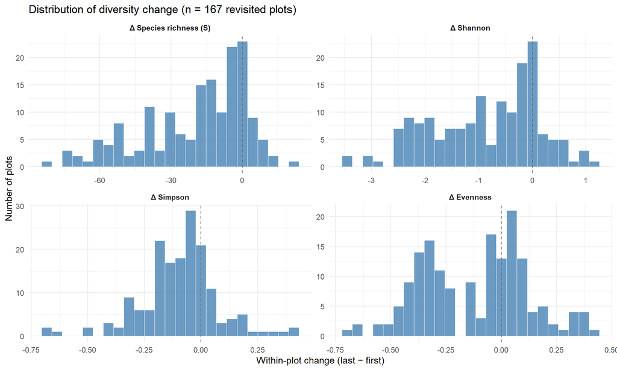

Panel A. Distribution of within-plot diversity change (first vs last survey).

```r
p_delta_diversity
```

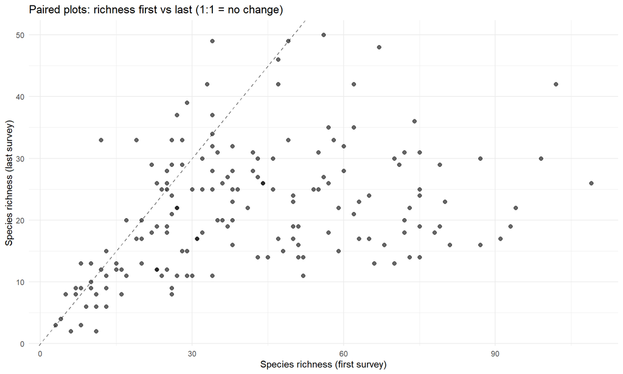

Panel B. Species richness first vs last survey (dashed line indicates no change).

```r
p_first_last_S
```

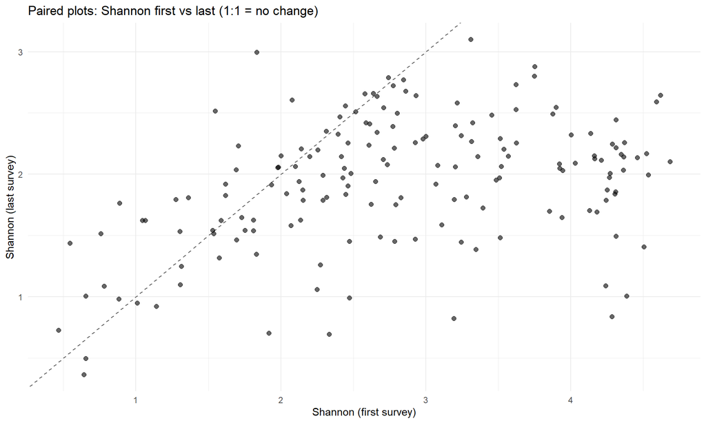

Panel C. Shannon diversity first vs last survey (dashed line indicates no change).

```r
p_first_last_Shannon
```

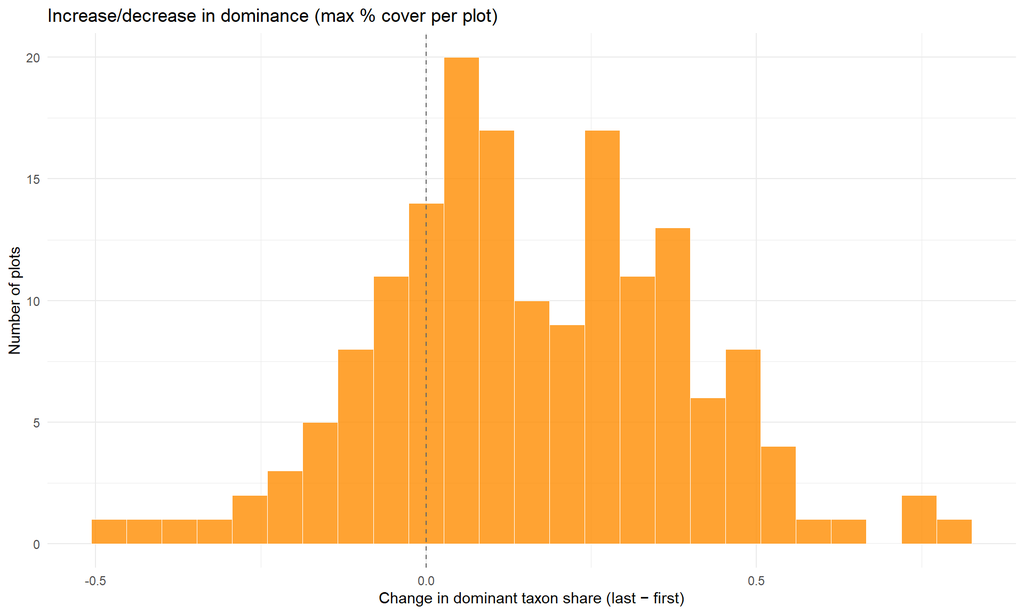

Panel D. Distribution of change in dominant taxon cover share by plot.

```r
p_delta_dominance
```

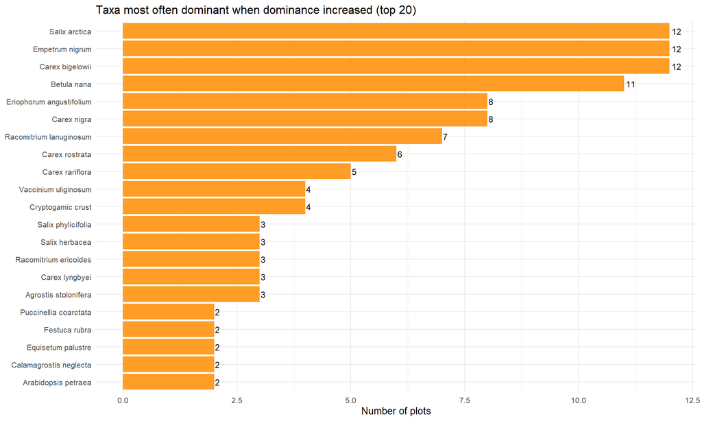

Panel E. Taxa most frequently dominant in plots where dominance increased.

```r
p_culprits
```

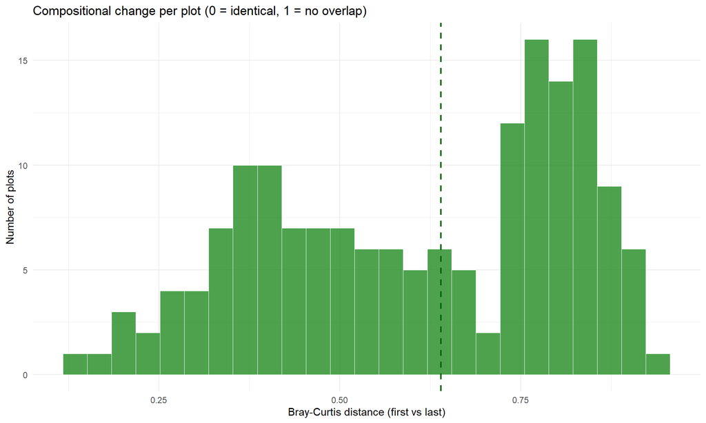

Panel F. Bray-Curtis dissimilarity between first and last survey per plot.

```r
p_bc_dist
```

## 0.8 8. Key interpretation for biologists

1. **Diversity metrics (S, Shannon, Simpson, Evenness):**  
   Most median changes are negative when diversity has declined in many paired plots.
2. **Dominance structure:**  
   Positive `delta_max_pct` indicates stronger concentration of cover in one top taxon.
3. **Taxon turnover in dominance:**  
   The Sankey highlights how first-survey dominant species transition to different final dominance ranks.
4. **Composition turnover (Bray-Curtis):**  
   Larger values indicate greater within-plot compositional shift over the revisit interval.

## 0.9 9. Reproducibility notes

- Input file: `plants_export/v_plants_allt.csv`
- Report logic: paired plots only (`n_years == 2`)
- Cover harmonization:
  - uses numeric `scale_value_value` if present,
  - otherwise maps Braun-Blanquet codes to midpoints.
- All results are regenerated from raw input inside this report.